# BIOS 611 Project 1

William King

10/7/2019

Urban Ministries of Durham is a charitable organization that has been providing food, clothing and other services to homeless individuals in the Durham area for over 30 years.

The social workers at UMD have been been recording much of their aid to clients in a database, which they have provided to us in a tsv file. All of the data for this project comes from this database.

As they are an organization that first and foremost is about helping people, I believe we should begin our analysis with their clients. One particular area that we were told is of interest to UMD is the length of time that their clients receive assistance for. They would like to know if there are any noticeable patterns among those who only need aid for a short time, and those who continue to need it for an extended period. I hope to help them shed some light on this question.

After tidying the data and clearing up typos, I first look into how long different clients received assistance for. We limit our data to the years 2000-2019 as they are most relevant and complete.

Let’s see if there are any patterns.

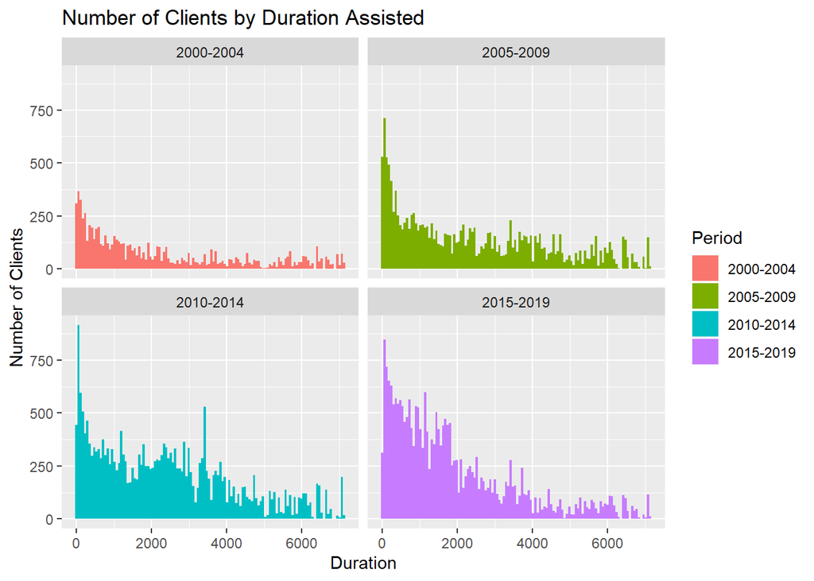

Considering the large number of clients who receive aid only once, it is worth looking at single-visit and repeat clients separately.

Let’s look at the frequency of visit for repeat clients.

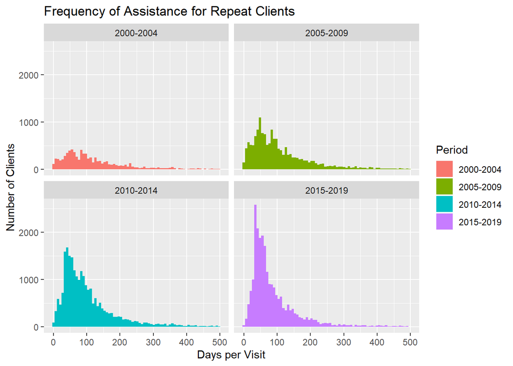

Here we can draw some useful observations about visit frequency:

- Most clients appear to receive assistance around once every 1-3 months (~30-90 days)
- The number of clients who receive frequent assistance has increased significantly over the years.
- The number of clients who receive very infrequent assistance seems to have slightly decreased.

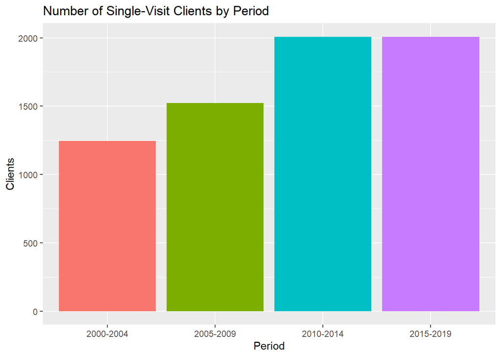

Here, we see that the number of single-visit clients increased by large numbers from 2004-2014, but has remained steady since 2014.

Let’s have a look at what months these single-visits occur on most and least frequently.

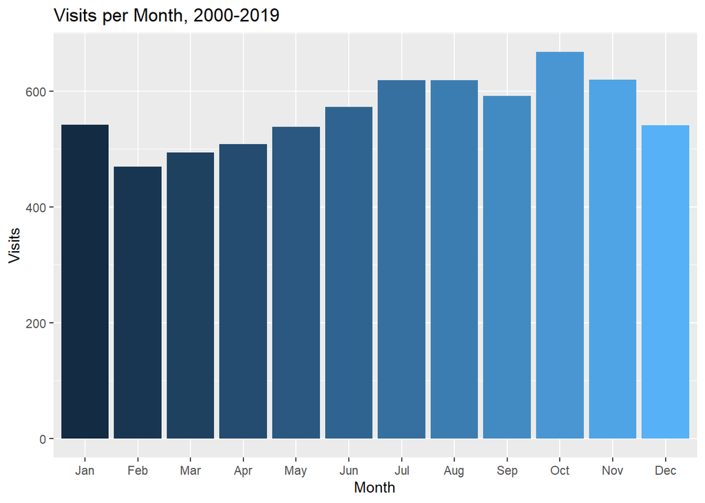

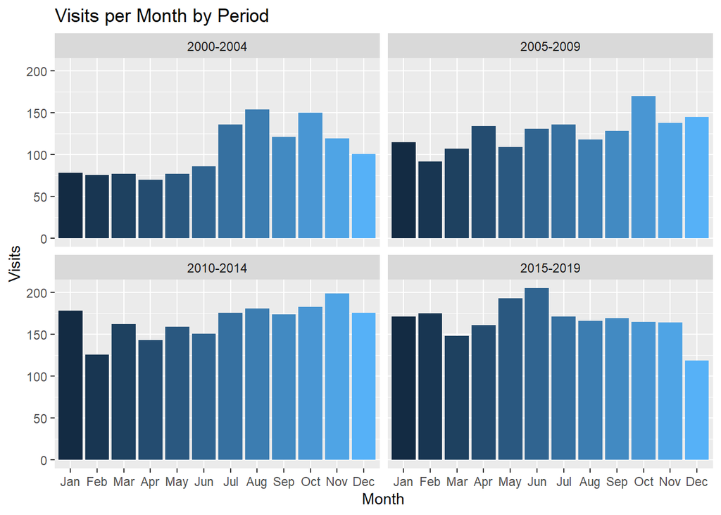

From our first graphs on assistance duration for clients, it appeared that the durations could be divided into several strata: 1. 1 Day  
2. 2 Days-6 Months  
3. 6 Months-1 Year  
4. 1-2 Years  
5. 2-5 Years  
6. 5-10 Years 7. 10+ Years

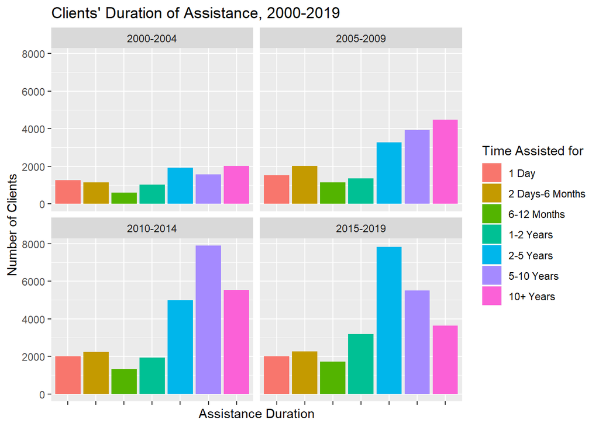

Some observations:

- 2-5 Years, 5-10 Years and 10+ Years have always been the three largest groups. This makes sense considering their wider time frame.
- Roughly an equal number of people receive help for one day as do for 2 days-6 months.
- Those receiving help for 6-12 months, 1-2 years and 2-5 years have steadily increased in number.
- After increasing over the first three periods, the 5-10 Years and 10+ Years groups both decreased in the last period
- 2-5 Years saw by far its biggest increase in the final period.

It would be helpful to analyze these groups further, to see if there are any differences in services provided that may be associated with longer or shorter periods of needing assistance.

From cursory analysis, the only variable that immediately shows any significant difference between these groups is Food Pounds.

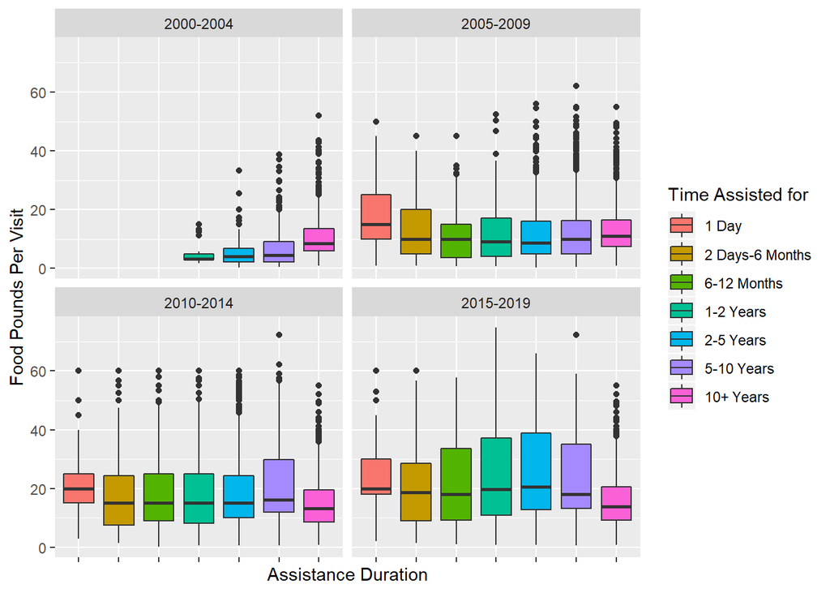

One thing I notice is that the 1-day clients appear to receive slightly more food per visit than others.

This could possibly suggest that clients who receive enough food on their first visit are less likely to need to return again. Alternatively, it could instead only be due to scarcity of resources that makes it difficult to give large amounts of food to clients over long periods of time. More analysis would be required to try to help answer this question.

So far, we have recognized some patterns in the duration of assistance for clients. These are good starting points from which to continue further analysis in a number of potential directions.

At this point, I feel it would be helpful to speak directly with our clients at Urban Ministries to see how they feel about the information we have reviewed so far. Further analysis is definitely required to be able to draw many worthwhile conclusions, and it would be helpful to hear from them what directions they would like to go in.